# Interactive Mapmaking with Python

Sangarshanan

# Data + Pandas <3

[figure not shown]

```python
import pandas
df = pandas.read_csv('data/cities.csv')
df.head()
```

|  | name | longitude | latitude |
| --- | --- | --- | --- |
| 0 | Vatican City | 12.453387 | 41.903282 |
| 1 | San Marino | 12.441770 | 43.936096 |
| 2 | Vaduz | 9.516669 | 47.133724 |
| 3 | Luxembourg | 6.130003 | 49.611660 |
| 4 | Palikir | 158.149974 | 6.916644 |

# Data with a location component

Geometries

- Point (latitude, longitude)
- Polygon [point1, point2]

We can also have linestrings, multipolygons, circles etc

# Enter GeoPandas

- Work with a Familiar interface (Dataframes), in this case Geodataframes
- Read/ write GIS data (Fiona) formats like shapefile, geojson, kml etc
- Perform spatial operations like merge/join/overlay etc (Shapely)
- Plot em on a map (Matplotlib)

Also a whole lot of other things like handling projections, recently added vectorized geometrical operations, Indexing with rtree... and more such goodies

Interested in more, https://github.com/jorisvandenbossche/geopandas-tutorial has a comprehensive tutorial by the maintainer

```python
df.head()
```

|  | name | longitude | latitude |
| --- | --- | --- | --- |
| 0 | Vatican City | 12.453387 | 41.903282 |
| 1 | San Marino | 12.441770 | 43.936096 |
| 2 | Vaduz | 9.516669 | 47.133724 |
| 3 | Luxembourg | 6.130003 | 49.611660 |
| 4 | Palikir | 158.149974 | 6.916644 |

```python
import geopandas
# Converting latitude, longitude to geometry object
gdf = geopandas.GeoDataFrame(
    df, geometry=geopandas.points_from_xy(df.longitude, df.latitude))
# setting the projection
gdf.crs = 'epsg:4326'
gdf.head()
```

|  | name | longitude | latitude | geometry |
| --- | --- | --- | --- | --- |
| 0 | Vatican City | 12.453387 | 41.903282 | POINT (12.45339 41.90328) |
| 1 | San Marino | 12.441770 | 43.936096 | POINT (12.44177 43.93610) |
| 2 | Vaduz | 9.516669 | 47.133724 | POINT (9.51667 47.13372) |
| 3 | Luxembourg | 6.130003 | 49.611660 | POINT (6.13000 49.61166) |
| 4 | Palikir | 158.149974 | 6.916644 | POINT (158.14997 6.91664) |

### How do I plot em ?

### With geopandas, its as simple as .plot()

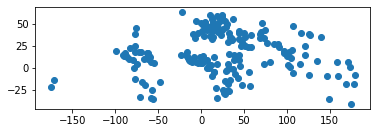

```python
import matplotlib.pyplot as plt
gdf.plot()
```

[figure not shown]

# Folium Plots

```python
gdf.head(1)
```

|  | name | longitude | latitude | geometry |
| --- | --- | --- | --- | --- |
| 0 | Vatican City | 12.453387 | 41.903282 | POINT (12.45339 41.90328) |

```python
# import the library
import folium
# Create a map with a center and zoom level
mapa = folium.Map(location= [-15.783333, -47.866667],
                  zoom_start= 1,
                  tiles= "OpenStreetMap")
mapa
```

[interactive chart not shown]

```python
# Add the geodataframe as a geojson feature
points = folium.features.GeoJson(gdf,
                                 # tooltip with the name
                                tooltip=folium.GeoJsonTooltip(fields=['name']))
# Adding the feature to the canvas we created
mapa.add_child(points)
mapa
```

[interactive chart not shown]

### Onward to Polygons

```python
world = geopandas.read_file(geopandas.datasets.get_path('naturalearth_lowres'))
world.head(2)
```

|  | pop_est | continent | name | iso_a3 | gdp_md_est | geometry |
| --- | --- | --- | --- | --- | --- | --- |
| 0 | 920938 | Oceania | Fiji | FJI | 8374.0 | MULTIPOLYGON (((180.00000 -16.06713, 180.00000... |
| 1 | 53950935 | Africa | Tanzania | TZA | 150600.0 | POLYGON ((33.90371 -0.95000, 34.07262 -1.05982... |

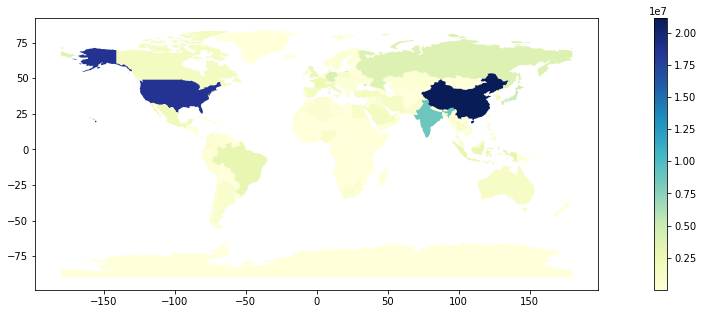

```python
#https://matplotlib.org/3.1.1/gallery/color/colormap_reference.html
world.plot(figsize=(20,5), column= 'gdp_md_est', cmap='YlGnBu', legend=True)
```

```python
import branca.colormap as cm
colormap = cm.linear.YlGnBu_09.to_step(data=world['gdp_md_est'], n=9)
colormap
```

[figure not shown]

```python
m = folium.Map()
# Setting the style
style_function = lambda x: {
    # How to fill color of the polygon
    'fillColor': colormap(x['properties']['gdp_md_est']),
    # Color of Polygon
    'color': 'black',
    # Weight of the border (Around the Polygon)
    'weight': 0.5,
    # Opacity of filled color
    'fillOpacity': 0.75
}
```

```python
# Creating a geojson map with the style
folium.GeoJson(
    world,
    tooltip=folium.GeoJsonTooltip(fields= ["name", "gdp_md_est"]),
    style_function=style_function
).add_to(m)
# Add the legend to the same canvas
colormap.add_to(m)
m
```

[interactive chart not shown]

## Marker Clusters

```python
from folium.plugins import MarkerCluster
locations = []
# City location geometries to a list of latlongs pairs
for idx, row in gdf.iterrows():
    locations.append([row['geometry'].y, row['geometry'].x])
# Empty canvas
m = folium.Map()
# Markercluster
m.add_child(MarkerCluster(locations=locations))
m
```

[interactive chart not shown]

# Heatmap

```python
from folium.plugins import HeatMap
m = folium.Map()
m.add_child(HeatMap(locations, radius=15))
m
```

[interactive chart not shown]

### Mo data Mo Problems

# kepler.gl

Kepler.gl is a data-agnostic, high-performance web-based application for visual exploration of large-scale geolocation data sets. Built on top of Mapbox GL and deck.gl, kepler.gl can render millions of points representing thousands of trips and perform spatial aggregations on the fly.

Jupyter Notebook > 5.3

`pip install keplergl`

JupyterLab

`jupyter labextension install @jupyter-widgets/jupyterlab-manager keplergl-jupyter`

[figure not shown]

### Kepler uses config to customize its maps

```
{
  "version": "v1",
  "config": {
    "visState": {
      "filters": [
        {
          "dataId": "earthquakes",
          "id": "vo18yorx",
        }
      ],
      "layers": [
        {
          "id": "hty62yd",
          "type": "point",
          "config": {
            "dataId": "earthquakes",
            "label": "Point",
            "color": [
              23,
              184,
              190
            ],
            "columns": {
              "lat": "Latitude",
              "lng": "Longitude",
              "altitude": null
            },
.....
```

### The UX flow is composed of five layers

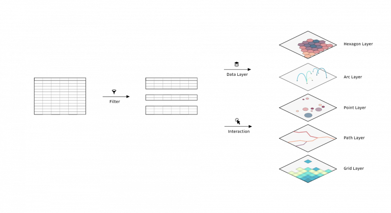

# Filters, Timelines and other cool perks

[figure not shown]

### Bokeh

```python
from bokeh.io import output_notebook
from bokeh.plotting import figure, output_file, show
from bokeh.tile_providers import CARTODBPOSITRON, get_provider
output_notebook()
tile_provider = get_provider(CARTODBPOSITRON)
p = figure(x_range=(-2000000, 6000000), y_range=(-1000000, 7000000),
           x_axis_type="mercator", y_axis_type="mercator")
p.add_tile(tile_provider)
show(p)
```

[figure not shown]

## Plotly

```python
import plotly.express as px
df = px.data.carshare()
fig = px.scatter_mapbox(df, lat="centroid_lat", lon="centroid_lon", color="peak_hour", size="car_hours",
                  color_continuous_scale=px.colors.cyclical.IceFire, size_max=15, zoom=10,
                  mapbox_style="carto-positron")
```

[figure not shown]

# Say hello to Geopatra 👋

https://github.com/sangarshanan/geopatra

https://geopatra.readthedocs.io/en/latest/

```python
import geopatra
gdf.folium.plot(zoom=2)
```

[interactive chart not shown]

# Yet another one, why ?

- Different libraries have different APIs
- All of them are awesome and have something new and exciting and offer
- Netflix Syndrome
- I wanna be able to switch between them without having to remember all the interfaces/ spend time googling

## Chloropeth maps

```python
world.folium.chloropeth(color_by= 'pop_est',
          color= 'green',
          zoom= 1,
          style = {'color': 'black',
                    'weight': 1,
                    'dashArray': '10, 5',
                    'fillOpacity': 0.5,
                  })
```

[interactive chart not shown]

## Circle Plots

```python
gdf.folium.circle(radius=10, fill=True, fill_color='red', zoom=100, color='blue')
```

[interactive chart not shown]

## Markercluster

```python
gdf.folium.markercluster(zoom=1, tooltip=["name"])
```

[interactive chart not shown]

## Weighted Markercluster

```python
import random
gdf['value'] = [int(random.randint(10, 1000)) for i in range(len(gdf))]
gdf.folium.markercluster(zoom=1, metric='sum', weight='value')
```

[interactive chart not shown]

## Heatmap

```python
gdf.folium.heatmap(style={'min_opacity': 0.3}, zoom=5)
```

[interactive chart not shown]

## Kepler.gl

```python
from IPython.display import IFrame
kmap1 = gdf.kepler.plot()
```

```
User Guide: https://docs.kepler.gl/docs/keplergl-jupyter
```

[figure not shown]

# Thank You : )

[figure not shown]